# Untitled

Teresa Domaszewska

May 2, 2017

## Project report

To perform given tasks, I downloaded the training and test data sets as .csv files and read them into R. The data set describes measurements from accelerometers on the belt, forearm, arm, and dumbell of 6 participants. They were asked to perform barbell lifts correctly and incorrectly in 5 different ways. I excluded the columns with missing data in the training data set and visualized it’s content, plotting the relationship of every variable and the variable “classe”, eg:

```r
library(caret)
```

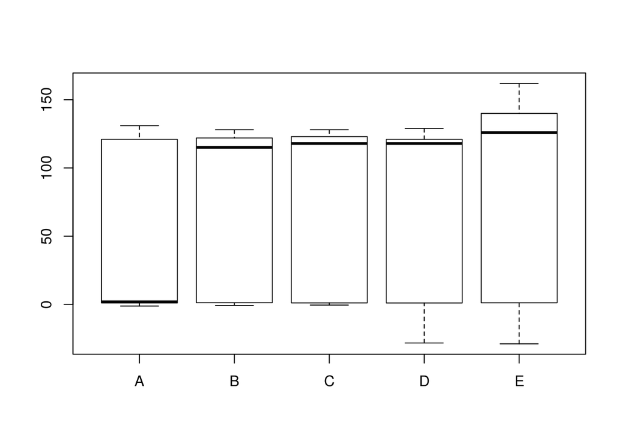

```r
testing <- read.csv("pml-testing.csv", header = TRUE)
training <- read.csv("pml-training.csv", header = TRUE)

training <- training [, -1]
testing <- testing [, -1]

training <- training [, colSums(is.na(training))<nrow(training)]
training <- training [, colSums(is.na(training))==0]
training <- training [, -c(11:19, 42:47, 51:59, 73:81)]
testing <- testing [, colSums(is.na(testing))<nrow(testing)]
testing <- testing [, colSums(is.na(testing))==0]

plot(training$classe, training$roll_belt)
```

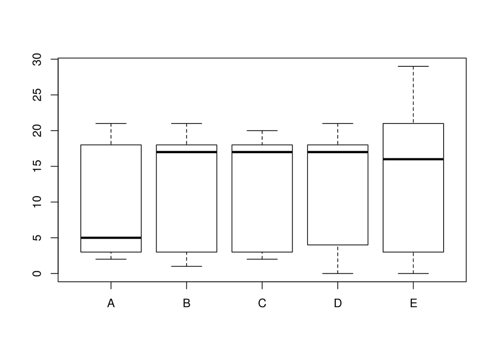

```r
plot(training$classe, training$total_accel_belt)
```

Some of the predictors presented bigger and some no influence on the predicted variable. Some of them could also be correlated. I decided to use all the predictors and random forest method without preprocessing to build the model with proximity measures calculated.

```r
modFit <- train(classe~., data=training, method = "rf", prox = TRUE)
pred <- predict(modFit, testing)
```

Cross validation has been performed as random sampling with replacement (bootstrapping) within the training data set. Reasampling results across tuning parameters:

```r
modFit$results
```

```
##   mtry  Accuracy     Kappa   AccuracySD      KappaSD
## 1    2 0.9906690 0.9881969 0.0016393392 0.0020718775
## 2   41 0.9990241 0.9987658 0.0002912514 0.0003683368
## 3   80 0.9982091 0.9977347 0.0007686285 0.0009732195
```

I decided to use random forest method including all predictors for which the data is available to include all available information in the model building.